# Buoy data analysis

Liz D. Ortiz Munoz

2025-01-07

# 1 **Purpose**

To evaluate how biogeochemical water quality variables interact and vary across wet and dry seasons in two urban canals (Coral Gables and Little River) using principal component analysis (PCA).

**Notes**

**DBHYDRO references**

- Coral Gables site G93 (DBKEY 64745): https://my.sfwmd.gov/dbhydroplsql/show_dbkey_info.date_selection?v_js_flag=Y&v_db_request_id=8750783&v_parameter_string=&v_dbkey=64745&v_frequency=&v_sdate=19911001&v_edate=20240326&v_datum=
- Little River site S27 (DBKEY 65069): https://my.sfwmd.gov/dbhydroplsql/show_dbkey_info.date_selection?v_js_flag=Y&v_db_request_id=8750772&v_parameter_string=&v_dbkey=65069&v_frequency=&v_sdate=19850531&v_edate=20240326&v_datum=
- Miami realtime portal: http://my.sfwmd.gov/portal/pls/portal/realtime.pkg_rr.proc_rr?p_op=MIAMI

# 2 **Libraries**

```r
# Install notes (optional):
# install.packages("astsa")
# install.packages("segmented")

library(astsa)
pacman::p_load(tidyverse, cowplot, lubridate, dplyr, dplR, zoo)

library(naniar)
library(DescTools)   # PlotACF function
library(WaveletComp)
library(matrixStats)
library(tidyr)
library(ggplot2)
library(readr)
library(gridExtra)
library(ggpubr)
library(viridis)

library(car)
library(devtools)
library(janitor)

library(neonOS)
library(terra)
library(imputeTS)
library(corrplot)
library(segmented)
library(rcompanion)
library(FactoMineR)
library(factoextra)
library(FSA)
library(rcompanion)
```

# 3 **Working directory**

```r
# If you did not start RStudio from the project file, set your working directory:
setwd("/Users/lizortiz/Library/CloudStorage/OneDrive-FloridaInternationalUniversity/SFWMD_discharge_precipitation")
```

# 4 **Load datasets**

```r
# merge buoy_data and discharge (only variables that I want)
new_data <- read.csv("new_data.csv")
head(new_data)
```

|  | Date | Canal | Year | Discharge | daily_EXO_fdom | daily_EXO_spCond | daily_EXO_sal_psu |
| --- | --- | --- | --- | --- | --- | --- | --- |
| 1 | 2021-04-21 | Coral_Gables | 2021 | 0 | 23.77316 | 22529.14 | 13.55211 |
| 2 | 2021-04-22 | Coral_Gables | 2021 | 0 | 23.14274 | 23639.76 | 14.29253 |
| 3 | 2021-04-23 | Coral_Gables | 2021 | 0 | 22.41802 | 25176.34 | 15.31135 |
| 4 | 2021-04-24 | Coral_Gables | 2021 | 0 | 22.07688 | 26225.94 | 15.99687 |
| 5 | 2021-04-25 | Coral_Gables | 2021 | 0 | 22.55750 | 25824.07 | 15.72438 |
| 6 | 2021-04-26 | Coral_Gables | 2021 | 0 | 22.84219 | 26763.70 | 16.35781 |

```r
tail(new_data)
```

|  | Date | Canal | Year | Discharge | daily_EXO_fdom | daily_EXO_spCond | daily_EXO_sal_psu |
| --- | --- | --- | --- | --- | --- | --- | --- |
| 2329 | 2024-06-25 | Little_River | 2024 | 831.2588 | 110.8744 | 14250.412 | 8.597396 |
| 2330 | 2024-06-26 | Little_River | 2024 | 1056.7520 | 113.6341 | 13014.185 | 7.836563 |
| 2331 | 2024-06-27 | Little_River | 2024 | 1064.2661 | 111.6509 | 11884.727 | 7.115417 |
| 2332 | 2024-06-28 | Little_River | 2024 | 979.5171 | 118.3822 | 11489.231 | 6.895313 |
| 2333 | 2024-06-29 | Little_River | 2024 | 941.2351 | 122.5439 | 8403.483 | 4.887083 |
| 2334 | 2024-06-30 | Little_River | 2024 | 886.0782 | 121.4923 | 7052.035 | 4.063438 |

```r
# merge new_data (buoy_data and discharge) with precipitation
new_data_prep <- read.csv("new_data_prep.csv")
head(new_data_prep)
```

|  | Date | Canal | Year | Discharge | daily_EXO_fdom | daily_EXO_spCond | daily_EXO_sal_psu | Precipitation_inches |
| --- | --- | --- | --- | --- | --- | --- | --- | --- |
| 1 | 2021-04-21 | Coral_Gables | 2021 | 0 | 23.77316 | 22529.14 | 13.55211 | 0.159 |
| 2 | 2021-04-22 | Coral_Gables | 2021 | 0 | 23.14274 | 23639.76 | 14.29253 | 0.022 |
| 3 | 2021-04-23 | Coral_Gables | 2021 | 0 | 22.41802 | 25176.34 | 15.31135 | 0.003 |
| 4 | 2021-04-24 | Coral_Gables | 2021 | 0 | 22.07688 | 26225.94 | 15.99687 | 0.005 |
| 5 | 2021-04-25 | Coral_Gables | 2021 | 0 | 22.55750 | 25824.07 | 15.72438 | 0.007 |
| 6 | 2021-04-26 | Coral_Gables | 2021 | 0 | 22.84219 | 26763.70 | 16.35781 | 0.063 |

```r
tail(new_data_prep)
```

|  | Date | Canal | Year | Discharge | daily_EXO_fdom | daily_EXO_spCond | daily_EXO_sal_psu | Precipitation_inches |
| --- | --- | --- | --- | --- | --- | --- | --- | --- |
| 2329 | 2024-06-25 | Little_River | 2024 | 831.2588 | 110.8744 | 14250.412 | 8.597396 | 0.05 |
| 2330 | 2024-06-26 | Little_River | 2024 | 1056.7520 | 113.6341 | 13014.185 | 7.836563 | 1.74 |
| 2331 | 2024-06-27 | Little_River | 2024 | 1064.2661 | 111.6509 | 11884.727 | 7.115417 | 0.00 |
| 2332 | 2024-06-28 | Little_River | 2024 | 979.5171 | 118.3822 | 11489.231 | 6.895313 | 0.00 |
| 2333 | 2024-06-29 | Little_River | 2024 | 941.2351 | 122.5439 | 8403.483 | 4.887083 | 0.00 |
| 2334 | 2024-06-30 | Little_River | 2024 | 886.0782 | 121.4923 | 7052.035 | 4.063438 | 1.77 |

```r
# merge all buoy variables with discharge and precipitation
new_data_all_final <- read.csv("new_data_all_final.csv")
head(new_data_all_final)
```

|  | Date | Canal | Year | Discharge | daily_EXO_fdom | daily_EXO_spCond | daily_EXO_do_mgL | daily_EXO_sal_psu | daily_EXO_depth | daily_EXO_pH | daily_EXO_chla_ugL | daily_EXO_Turbidity_NTU | daily_EXO_spCond_ZT | daily_EXO_do_mgL_ZT | daily_EXO_sal_psu_ZT | daily_EXO_pH_ZT | daily_EXO_chla_ugL_ZT | daily_EXO_Turbidity_NTU_ZT | Precipitation_inches |
| --- | --- | --- | --- | --- | --- | --- | --- | --- | --- | --- | --- | --- | --- | --- | --- | --- | --- | --- | --- |
| 1 | 2021-04-21 | Coral_Gables | 2021 | 0 | 23.77316 | 22529.14 | 4.650421 | 13.55211 | 0.2203158 | 7.591579 | 6.023158 | 0 | 0.7246450 | -0.2796914 | 0.7184494 | 0.4003833 | -0.13767189 | -0.2444071 | 0.159 |
| 2 | 2021-04-22 | Coral_Gables | 2021 | 0 | 23.14274 | 23639.76 | 4.423895 | 14.29253 | 0.2275053 | 7.576632 | 6.457789 | 0 | 0.8640971 | -0.4524741 | 0.8666705 | 0.3623959 | -0.04099499 | -0.2444071 | 0.022 |
| 3 | 2021-04-23 | Coral_Gables | 2021 | 0 | 22.41802 | 25176.34 | 4.774167 | 15.31135 | 0.2365312 | 7.619375 | 7.770417 | 0 | 1.0570351 | -0.1853047 | 1.0706244 | 0.4710245 | 0.25097810 | -0.2444071 | 0.003 |
| 4 | 2021-04-24 | Coral_Gables | 2021 | 0 | 22.07688 | 26225.94 | 5.228438 | 15.99687 | 0.2080417 | 7.658021 | 8.083021 | 0 | 1.1888255 | 0.1611898 | 1.2078552 | 0.5692395 | 0.32051194 | -0.2444071 | 0.005 |
| 5 | 2021-04-25 | Coral_Gables | 2021 | 0 | 22.55750 | 25824.07 | 5.397500 | 15.72438 | 0.1718542 | 7.650938 | 7.118125 | 0 | 1.1383651 | 0.2901420 | 1.1533049 | 0.5512379 | 0.10588617 | -0.2444071 | 0.007 |
| 6 | 2021-04-26 | Coral_Gables | 2021 | 0 | 22.84219 | 26763.70 | 5.269583 | 16.35781 | 0.1909896 | 7.644792 | 6.831563 | 0 | 1.2563486 | 0.1925737 | 1.2801094 | 0.5356188 | 0.04214489 | -0.2444071 | 0.063 |

```r
tail(new_data_all_final)
```

|  | Date | Canal | Year | Discharge | daily_EXO_fdom | daily_EXO_spCond | daily_EXO_do_mgL | daily_EXO_sal_psu | daily_EXO_depth | daily_EXO_pH | daily_EXO_chla_ugL | daily_EXO_Turbidity_NTU | daily_EXO_spCond_ZT | daily_EXO_do_mgL_ZT | daily_EXO_sal_psu_ZT | daily_EXO_pH_ZT | daily_EXO_chla_ugL_ZT | daily_EXO_Turbidity_NTU_ZT | Precipitation_inches |
| --- | --- | --- | --- | --- | --- | --- | --- | --- | --- | --- | --- | --- | --- | --- | --- | --- | --- | --- | --- |
| 2329 | 2024-06-25 | Little_River | 2024 | 831.2588 | 110.8744 | 14250.412 | 2.733229 | 8.597396 | 0.6283854 | 7.413229 | 4.953646 | 3.574583 | -0.6074038 | -1.4574157 | -0.5983758 | -0.06614287 | 0.7180814 | 0.02852492 | 0.05 |
| 2330 | 2024-06-26 | Little_River | 2024 | 1056.7520 | 113.6341 | 13014.185 | 2.689792 | 7.836563 | 0.6285104 | 7.398229 | 4.648125 | 4.048542 | -0.7281407 | -1.4943931 | -0.7112771 | -0.10629583 | 0.5547025 | 0.10404467 | 1.74 |
| 2331 | 2024-06-27 | Little_River | 2024 | 1064.2661 | 111.6509 | 11884.727 | 2.935521 | 7.115417 | 0.6221562 | 7.397708 | 4.020521 | 3.940104 | -0.8384499 | -1.2852095 | -0.8182892 | -0.10769003 | 0.2190878 | 0.08676641 | 0.00 |
| 2332 | 2024-06-28 | Little_River | 2024 | 979.5171 | 118.3822 | 11489.231 | 3.196354 | 6.895313 | 0.6450729 | 7.402188 | 4.880625 | 3.555521 | -0.8770763 | -1.0631680 | -0.8509509 | -0.09569991 | 0.6790331 | 0.02548753 | 0.00 |
| 2333 | 2024-06-29 | Little_River | 2024 | 941.2351 | 122.5439 | 8403.483 | 3.603854 | 4.887083 | 0.6784375 | 7.401771 | 4.371458 | 3.469896 | -1.1784477 | -0.7162726 | -1.1489555 | -0.09681527 | 0.4067535 | 0.01184418 | 0.00 |
| 2334 | 2024-06-30 | Little_River | 2024 | 886.0782 | 121.4923 | 7052.035 | 3.234688 | 4.063438 | 0.6754583 | 7.379896 | 3.849583 | 3.154479 | -1.3104377 | -1.0305357 | -1.2711777 | -0.15537168 | 0.1276780 | -0.03841379 | 1.77 |

# 5 **Data adjustments and filtering**

```r
# Add wet/dry seasons + split date
new_data_all_final_2 <- new_data_all_final %>%
  separate(Date, into = c("Year", "Month", "Day"), sep = "-", remove = FALSE) %>%
  mutate(
    Year  = as.character(Year),
    Month = as.character(Month),
    Day   = as.character(Day)
  )

new_data_all_final_2$Seasons <- ifelse(
  grepl("5|6|7|8|9|10", new_data_all_final_2$Month, ignore.case = TRUE),
  "Wet",
  "Dry"
)

# Replace original
new_data_all_final <- new_data_all_final_2

# Convert discharge to Q (m3/s)
new_data_all_final$Q <- new_data_all_final$Discharge * 0.028316846592

# Ensure Date class
new_data_all_final$Date <- as.Date(new_data_all_final$Date)

# Remove rows between 2021-11-11 and 2021-11-23 (bad temp/cond values)
new_data_all_final_filtered <- new_data_all_final %>%
  filter(!(Date >= as.Date("2021-11-11") & Date <= as.Date("2021-11-23")))

# Remove pH outliers
new_data_all_final_filtered_2 <- new_data_all_final_filtered %>%
  mutate(daily_EXO_pH = ifelse(daily_EXO_pH < 5 | daily_EXO_pH > 10, NA, daily_EXO_pH))

# Final working dataset
new_data_2 <- new_data_all_final_filtered_2

# Save
write.csv(new_data_2, "new_data_2_20260216.csv", row.names = FALSE)

# Subset canals
new_data_2_coral <- subset(new_data_all_final_filtered_2, Canal == "Coral_Gables")
new_data_2_river <- subset(new_data_all_final_filtered_2, Canal == "Little_River")

dat2 <- subset(new_data_all_final_filtered_2, Canal == "Little_River")
dat  <- subset(new_data_all_final_filtered_2, Canal == "Coral_Gables")
```

# 6 **PCA: Little River**

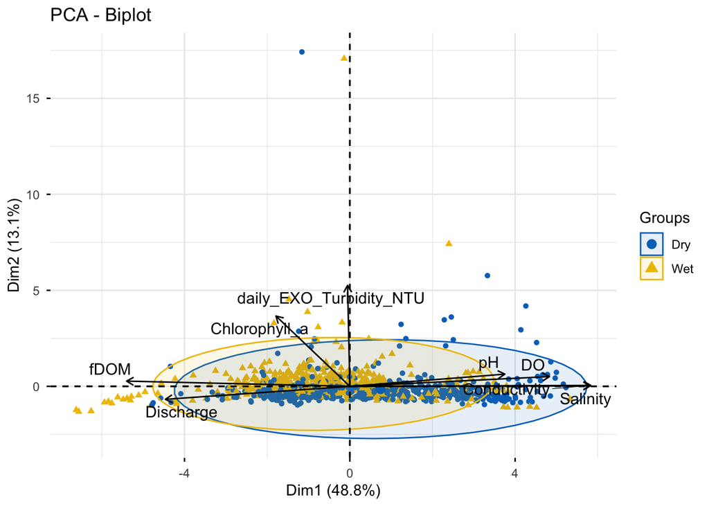

```r
bio_variables_little <- dat2[, c(
  "daily_EXO_fdom",
  "daily_EXO_spCond",
  "daily_EXO_do_mgL",
  "daily_EXO_sal_psu",
  "daily_EXO_pH",
  "daily_EXO_chla_ugL",
  "Q",
  "daily_EXO_Turbidity_NTU",
  "Year",
  "Seasons",
  "Month"
)]

bio_variables_little$Month <- as.character(bio_variables_little$Month)
bio_variables_little <- na.omit(bio_variables_little)

bio_variables_little <- bio_variables_little %>%
  dplyr::rename(
    fDOM          = daily_EXO_fdom,
    Conductivity  = daily_EXO_spCond,
    DO            = daily_EXO_do_mgL,
    Salinity      = daily_EXO_sal_psu,
    pH            = daily_EXO_pH,
    Chlorophyll_a = daily_EXO_chla_ugL,
    Discharge     = Q
  )

iris.pca_little <- PCA(bio_variables_little[, c(1:8)], scale = TRUE, graph = FALSE)

fviz_pca_biplot(
  iris.pca_little,
  col.ind = bio_variables_little$Seasons,
  palette = "jco",
  label = "var",
  col.var = "black",
  repel = TRUE,
  addEllipses = TRUE,
  legend.title = "Groups"
)
```

## 6.1 **PC scores + seasonal comparison (Little River)**

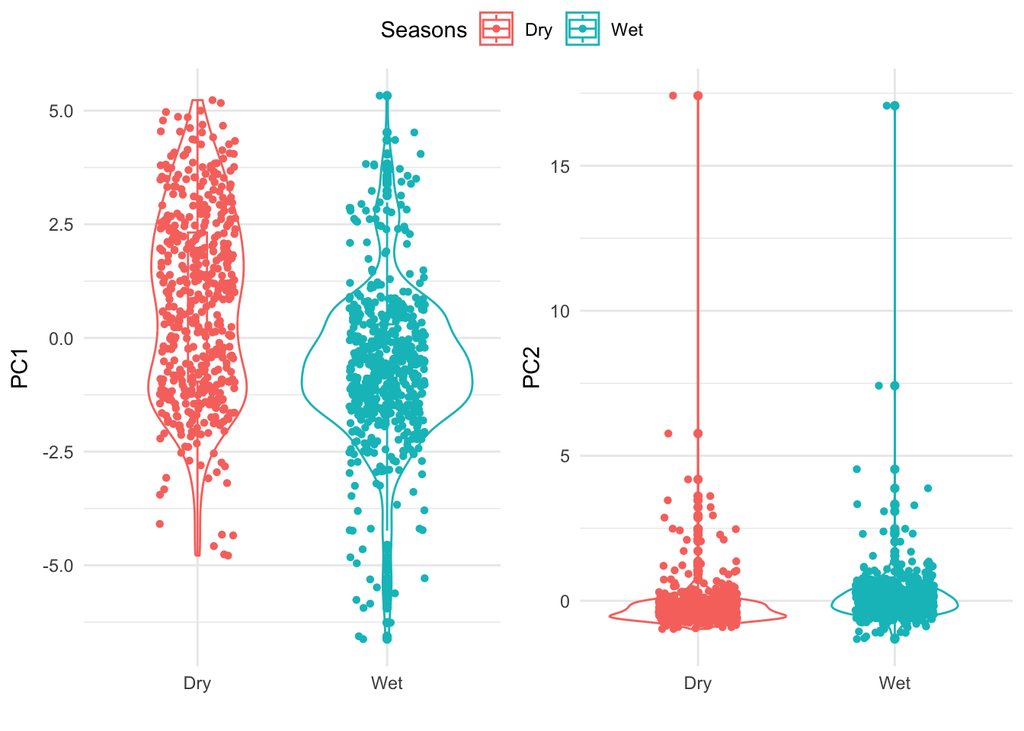

```r
scores_little <- as.data.frame(iris.pca_little$ind$coord)
bio_variables_little$PC1 <- scores_little$Dim.1
bio_variables_little$PC2 <- scores_little$Dim.2



pca1_box_little <- ggplot(bio_variables_little, aes(y = PC1, x = Seasons, color = Seasons)) +
  geom_violin() +
  geom_boxplot(width = 0.1) +
  geom_jitter(shape = 16, position = position_jitter(0.2)) +
  labs(x = "", y = "PC1", color = "Seasons") +
  theme_minimal()

pca2_box_little <- ggplot(bio_variables_little, aes(y = PC2, x = Seasons, color = Seasons)) +
  geom_violin() +
  geom_boxplot(width = 0.1) +
  geom_jitter(shape = 16, position = position_jitter(0.2)) +
  labs(x = "", y = "PC2", color = "Seasons") +
  theme_minimal()

pca_box_little <- ggarrange(
  pca1_box_little, pca2_box_little,
  ncol = 2,
  common.legend = TRUE
)

pca_box_little
```

## 6.2 **Stats: Little River (Kruskal + Dunn + CLD)**

```r
kruskal.test(PC1 ~ Seasons, data = bio_variables_little)
```

```
##
##  Kruskal-Wallis rank sum test
##
## data:  PC1 by Seasons
## Kruskal-Wallis chi-squared = 116.08, df = 1, p-value < 2.2e-16
```

```r
dunn_results <- dunnTest(PC1 ~ Seasons, data = bio_variables_little, method = "bonferroni")
p_table <- dunn_results$res
cld <- cldList(P.adj ~ Comparison, data = p_table, threshold = 0.05)
print(cld)
```

```
##   Group Letter MonoLetter
## 1   Dry      a         a
## 2   Wet      b          b
```

```r
kruskal.test(PC2 ~ Seasons, data = bio_variables_little)
```

```
##
##  Kruskal-Wallis rank sum test
##
## data:  PC2 by Seasons
## Kruskal-Wallis chi-squared = 119.76, df = 1, p-value < 2.2e-16
```

```r
dunn_results <- dunnTest(PC2 ~ Seasons, data = bio_variables_little, method = "bonferroni")
p_table <- dunn_results$res
cld <- cldList(P.adj ~ Comparison, data = p_table, threshold = 0.05)
print(cld)
```

```
##   Group Letter MonoLetter
## 1   Dry      a         a
## 2   Wet      b          b
```

# 7 **PCA: Coral Gables**

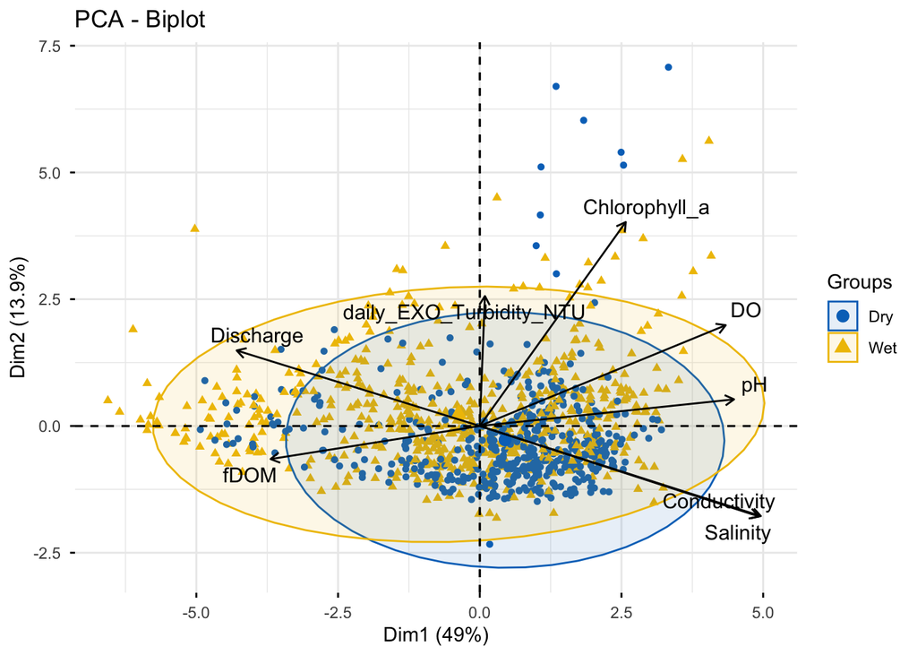

```r
bio_variables <- dat[, c(
  "daily_EXO_fdom",
  "daily_EXO_spCond",
  "daily_EXO_do_mgL",
  "daily_EXO_sal_psu",
  "daily_EXO_pH",
  "daily_EXO_chla_ugL",
  "Q",
  "daily_EXO_Turbidity_NTU",
  "Year",
  "Seasons",
  "Month"
)]

bio_variables$Month <- as.character(bio_variables$Month)
bio_variables <- na.omit(bio_variables)

bio_variables <- bio_variables %>%
  dplyr::rename(
    fDOM          = daily_EXO_fdom,
    Conductivity  = daily_EXO_spCond,
    DO            = daily_EXO_do_mgL,
    Salinity      = daily_EXO_sal_psu,
    pH            = daily_EXO_pH,
    Chlorophyll_a = daily_EXO_chla_ugL,
    Discharge     = Q
  )

iris.pca <- PCA(bio_variables[, c(1:8)], scale = TRUE, graph = FALSE)

fviz_pca_biplot(
  iris.pca,
  col.ind = bio_variables$Seasons,
  palette = "jco",
  label = "var",
  col.var = "black",
  repel = TRUE,
  addEllipses = TRUE,
  legend.title = "Groups"
)
```

## 7.1 **PC scores + seasonal comparison (Coral Gables)**

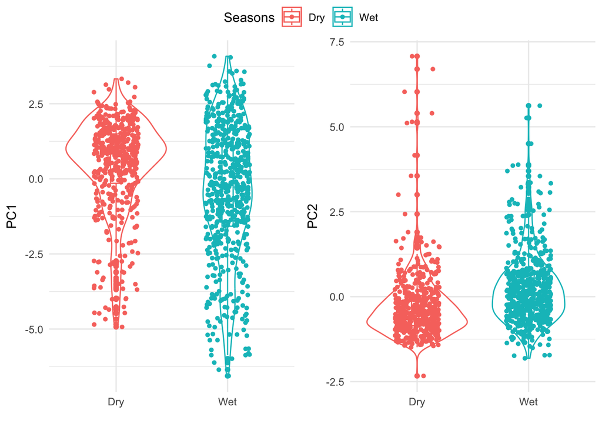

```r
scores <- as.data.frame(iris.pca$ind$coord)
bio_variables$PC1 <- scores$Dim.1
bio_variables$PC2 <- scores$Dim.2

pca1_box_coral <- ggplot(bio_variables, aes(y = PC1, x = Seasons, color = Seasons)) +
  geom_violin() +
  geom_boxplot(width = 0.1) +
  geom_jitter(shape = 16, position = position_jitter(0.2)) +
  labs(x = "", y = "PC1", color = "Seasons") +
  theme_minimal()

pca2_box_coral <- ggplot(bio_variables, aes(y = PC2, x = Seasons, color = Seasons)) +
  geom_violin() +
  geom_boxplot(width = 0.1) +
  geom_jitter(shape = 16, position = position_jitter(0.2)) +
  labs(x = "", y = "PC2", color = "Seasons") +
  theme_minimal()

pca_box_coral <- ggarrange(
  pca1_box_coral, pca2_box_coral,
  ncol = 2,
  common.legend = TRUE
)

pca_box_coral
```

## 7.2 **Stats: Coral Gables (Kruskal + Dunn + CLD)**

```r
kruskal.test(PC1 ~ Seasons, data = bio_variables)
```

```
##
##  Kruskal-Wallis rank sum test
##
## data:  PC1 by Seasons
## Kruskal-Wallis chi-squared = 41.098, df = 1, p-value = 1.448e-10
```

```r
dunn_results <- dunnTest(PC1 ~ Seasons, data = bio_variables, method = "bonferroni")
p_table <- dunn_results$res
cld <- cldList(P.adj ~ Comparison, data = p_table, threshold = 0.05)
print(cld)
```

```
##   Group Letter MonoLetter
## 1   Dry      a         a
## 2   Wet      b          b
```

```r
kruskal.test(PC2 ~ Seasons, data = bio_variables)
```

```
##
##  Kruskal-Wallis rank sum test
##
## data:  PC2 by Seasons
## Kruskal-Wallis chi-squared = 104.74, df = 1, p-value < 2.2e-16
```

```r
dunn_results <- dunnTest(PC2 ~ Seasons, data = bio_variables, method = "bonferroni")
p_table <- dunn_results$res
cld <- cldList(P.adj ~ Comparison, data = p_table, threshold = 0.05)
print(cld)
```

```
##   Group Letter MonoLetter
## 1   Dry      a         a
## 2   Wet      b          b
```

# 8 **Results**

## 8.1 **Little River**

- A PCA of Little River water quality variables showed clear seasonal separation. PC1 (48.8% of variance) primarily represents a gradient from higher salinity, conductivity, DO, and pH (marine influence) to higher discharge and fDOM (freshwater influence). The wet season tends to shift toward the freshwater–discharge–fDOM side, whereas the dry season is associated with higher salinity and conductivity, suggesting stronger marine influence.
- Statistical tests confirmed these seasonal differences, as PC1 and PC2 both differed significantly between wet and dry seasons (Kruskal–Wallis p < 2.2×10⁻¹⁶). This indicates that hydrological seasonality strongly structures water quality conditions in Little River.

## 8.2 **Coral Gables**

- A PCA of Coral Gables water quality variables also showed clear seasonal differences. PC1 (49% of variance) represents a gradient from higher salinity, conductivity, DO, and pH (marine influence) to higher discharge and fDOM (freshwater influence). The dry season is more associated with the marine-influenced side of the gradient, while the wet season shifts toward higher discharge and fDOM conditions.
- Seasonal differences were statistically significant for both PC1 (p = 1.45 × 10⁻¹⁰) and PC2 (p < 2.2 × 10⁻¹⁶), indicating that seasonal hydrology significantly influences water quality dynamics in Coral Gables Canal.